# A4: Incarceration

Drew King

08/02/2023

### Introduction

Mass incarceration in the United States is an alarming trend that is on the rise. The United States has the most incarcerated people per capita in the world. In this report, the average prison incarceration per county since 1990 is analyzed by, race, population, and geographic boundaries (States). The analysis is done in this manner to show how there are disparities in incarceration by geographic region and ethnicity.

### Summary Information

The average total change in Incarceration rates from 1990 to 2016 by type of incarceration and race was computed and shown in the following table. This was done to show which racial groups are going into which carceral system. There was not enough data on AAPI populations to include them. The BIPOC variable is an aggregation of black and indigenous people who were incarcerated. Data on Latinx populations was not included due to time constraints and specification requirements of this report. Lastly, the total rate of increase in prison incarceration from 1970 to 2016 was calculated to show the scope of the issue of rising incarceration in the United States, this data is shown below the table.

| Race | Average Prison Change | Average Jail Change |
| --- | --- | --- |
| BIPOC | 1359.9722 | -549.4679 |
| White | 352.2551 | 330.9487 |

```
## Percent population growth in US prisons from 1970 to 2016 is 60.4688%
```

### The Dataset

Who collected the data?

- The Vera Institute of Justice

How was the data collected or generated?

- The data was aggregated from several sources including:
  - U.S. Department of Justice Bureau of Justice Statistics (BJS)
  - The U.S. Census Bureau
  - The Centers for Disease Control and Prevention (CDC)
  - The U.S. Department of Agriculture (USDA)
- The BJS data was compiled to record trends about incarcerated populations, while the other three agencies were used to get population data by county for each year. Why was the data collected?
- This data was collected to obtain a more granular look at incarceration in the United States, since incarceration occurs in decisions made by counties, not by states.

How many observations (rows) are in your data and how many features (columns) are in the data?

| Dimensions | prison_pop | jail_pop | prison_jail_rate_1990 |
| --- | --- | --- | --- |
| Columns | 37 | 29 | 26 |
| Rows | 153811 | 153811 | 91031 |

What, if any, ethical questions or questions of power do you need to consider when working with this data?

- Who is incarcerated the most and why?
- Where are people being incarcerated the most?
- Does race play a role in incarceration?

What are possible limitations or problems with this data?

- There is missing data on AAPI populations in the 1990 Prison Jail data-set.
- The data-set that goes back to 1970 is missing a lot of values for population by both race and gender.
- Some of the data would be easier to use if it were aggregated, such as the Prison Jail 1990 dataset along with the Prison Jail Rate 1990 dataset.

### Trends Over Time Chart: Incarceration by Race

Incarceration by race since 1990 was visualized in this report to create more understanding about:

- Increases in incarceration by year
- Who is being incarcerated the most
- Where people are being incarcerated

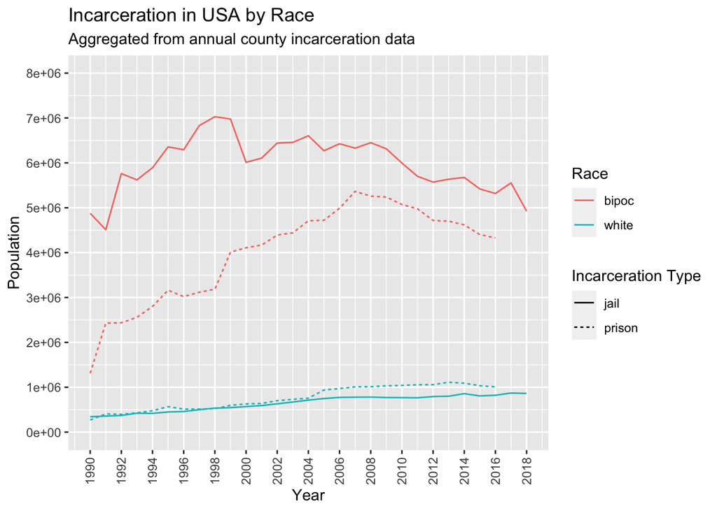

Key Findings:

- Black and Indigenous People are an overwhelming majority of the United States carceral population.
- Jail rates and prison rates are steadily rising for white people.
- Incarceration of the BIPOC population is cooling down since 2008, but still much higher than that of white people.

### Variable Comparison Chart: Population Growth vs Prison Growth

Incarceration by population growth was visualized as a scatter plot in this report to see if there is a correlation between population growth and incarceration growth from 1990 to 2016. Some technical limitations required that only the top 10 most incarcerated states be shown including:

- Color encoding is indiscernible for more than 10 states in the legend.
- A legend for all 50 states and if their prisons are growing is too large
- Some states have shrinking incarcerated populations, making it harder to fit a trend line.

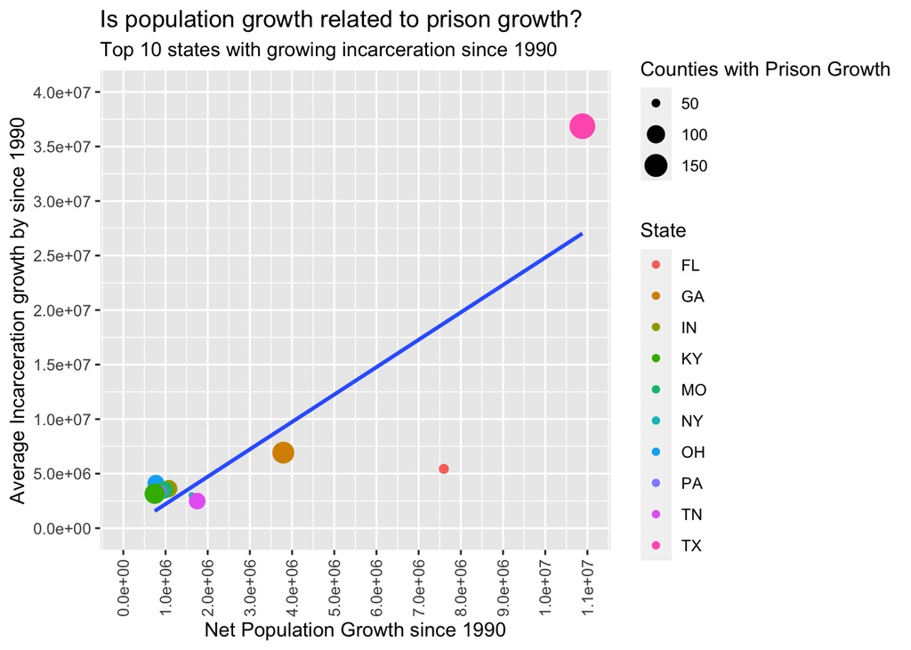

### Map: Incarceration Growth by State

Incarceration rates have been growing in the USA at alarming rates, in particular among BIPOC. Since the United States is not evenly distributed racially, this report includes a chart of incarceration growth since 1990 by state. Some technical limitations required that a logarithmic scale of incarceration growth be shown including:

- States where incarceration is growing are so much larger than the numbers in states where incarceration is shrinking
- The colors for states with low incarceration growth were close to the colors of the states with no incarceration growth or missing data.
- Numbers in the tens of millions do not fit well in the legend of the plot.

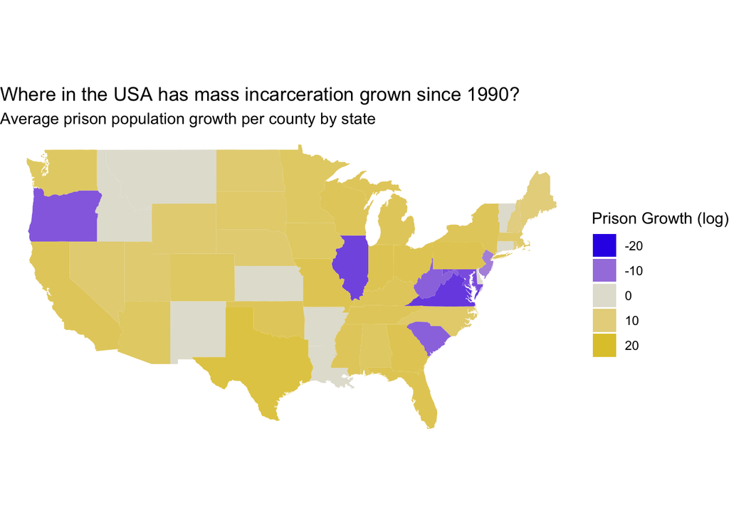

Key findings:

- States with the fastest growing incarceration rates are states that are home to many BIPOC individuals such as Texas, Georgia, and Flordia.
- Texas has the most prison growth (consistent with the scatterplot).
- Virginia has the most declining prison population, followed by Illinois, and Oregon.
- Several states with very high prison growth are also states that run for profit prisons, such as Texas and California.
- Discrepancy in prison population seems to defy party lines, since there is no correlation between red and blue states and prison growth.